# Estudio de personas con discapacidad en el año 2012

Si son requeridas instalamos e inicializamos las librerías necesarias

```r
library(readxl)
library(lessR)
library(plyr)
library(dplyr)
library(tidyr)
library(tidyverse)
library(car)
library(stringr)
library(writexl)
library(reshape2)
```

```r
library(ggplot2)
library(graphics)
```

Establecemos una función de redondeo

```r
redondeo <- function(x){
  return(round(x, digits = 2))
}
```

## **Introducción**

Hoy en día la educación es algo primordial en la mayoría de personas,sean niños, jóvenes o adultos, pero debido a las condiciones de algunas personas, estas no pueden acceder a la educación correspondiente. Es por eso que como grupo, hemos elegido como tema la accesibilidad que tenían las personas a la educación en el año 2012, principalmente enfocado en las personas que cuentan con algún tipo de discapacidad. También queríamos saber si el Perú se encontraba en condiciones óptimas para poder brindarles la educación correspondiente a este grupo de personas.

## **Relevancia**

Consideramos que estudiar la accesibilidad que tenían las personas a los estudios es un tema sumamente importante hoy en día, ya que la educación es algo primordial debido a que la calidad de vida que este tendrá en el futuro se basará prácticamente en eso. El tener acceso a la educación es un derecho constitucional también referido en la ley general de la educación Nro. 28044 Artículo 3 la cual dice “La educación es un derecho fundamental de la persona y de la sociedad. El Estado garantiza el ejercicio del derecho a una educación integral y de calidad para todos y la universalización de la Educación Básica. La sociedad tiene la responsabilidad de contribuir a la educación y el derecho a participar en su desarrollo.”. Con este estudio pretendemos saber si en el año 2012 se cumplía este derecho para todas las personas con alguna discapacidad o limitación.

# **Objetivos**

## **Generales**

Conocer si la infraestructura educativa peruana estaba preparada para personas con discapacidades.

## **Específicos**

- Saber si las diferentes discapacidades afectan en el rendimiento educativo de una persona.
- Encontrar cuál es la discapacidad más común en los hombres y mujeres.
- Conocer cuánto impacta la infraestructura escolar en las personas con discapacidad.

# **Datos**

## **Recolección de datos:**

Nosotros obtuvimos nuestra data del INEI, la cual se refieren al nivel de acceso de la población a la educación en los distintos departamentos del Perú con alguna limitación o discapacidad, a los servicios de la educación de tipo regular y no regular, las razones por las que no accede a la educación. Así como, se desea saber las características socioculturales de esta población.

## **Población, muestra y muestreo**

- Población: Población de distintas regiones del Perú
- Muestra: Nuestra muestra consiste de personas de la población del Perú con alguna discapacidad o limitación.
- Muestreo: La encuesta realizada por el INEI fue del tipo por conveniencia

## **Variables:**

| **VARIABLES** | **TIPOS DE VARIABLE** | **RESTRICCIONES** |
| --- | --- | --- |
| *Departamento* | *Cualitativa Nominal* | *Lugar de procedencia del sujeto entrevistado* |
| *Genero* | *Cualitativa Nominal* | *Si es Masculino (Hombre) o si es Femenino (Mujer)* |
| *Edad* | *Cuantitativa Discreta* | *Edad del participante mayor a 3, tomando números enteros positivos* |
| *Limitacion_permanente_extremidades* | *Cualitativa Nominal* | *Si la persona tiene discapacidad por falta de alguna extremidad solo se puede reponder con (Si) o (No)* |
| *Limitacion_permanente_vista* | *Cualitativa Nominal* | *Si presenta dificultad para poder ver (Si) en caso contrario (No)* |
| *Limitacion_permanente_habla* | *Cualitativa Nominal* | *Si presenta dificultad para poder comunicarse (Si) en caso contrario (No)* |
| *Limitacion_permanente_oido* | *Cualitativa Nominal* | *Si presenta dificultad para poder oir (Si) en caso contrario (No)* |
| *Limitacion_permanente_aprender* | *Cualitativa Nominal* | *Si presenta presenta alguna limitación mental(Si) en caso contrario(No)* |
| *Limitacion_permanente_relacionarse* | *Cualitativa Nominal* | *Le impide poder relacionarse con los demas(Si) en caso contrario(No)* |
| *Enfermedad_cronica_limita_actividades* | *Cualitativa Nominal* | *La persona padece de alguna enfermedad crónica(Si) en caso contrario(No)* |
| *Tiene_alguna_limitacion* | *Cualitativa Nominal* | *La persona posee algún tipo de limitación(Si) en caso contraio(No)* |
| *Ultimos_12_meses_en_programa_alfabetizacion* | *Cualitativa Nominal* | *La persona con discapacidad asistió a un programa de alfabetización(Si) en caso contrario(No)* |
| *Colegio_con_profesores_especializados* | *Cualitativa Nominal* | *Dispone de personal capacitado y apto(Si) en caso contrario(No), y si desconoce del tema(NEP)* |
| *Colegio_con_computadoras_especializadas* | *Cualitativa Nominal* | *Dispone de equipos adecuados(Si) en caso contrario(No), y si desconoce del tema(NEP)* |
| *Colegio_con_reproductor_audio_y_video* | *Cualitativa Nominal* | *Dispone de equipos de reproducción de audio y video(Si) en caso contrario(No), y si desconoce del tema(NEP)* |
| *Colegio_con_impresora_braille* | *Cualitativa Nominal* | *Dispone de impresora Braille(Si) en caso contrario(No), y si desconoce del tema(NEP)* |
| *Colegio_con_libros_braille* | *Cualitativa Nominal* | *Dispone de libros Braille (regleta y punzón)(Si) en caso contrario(No), y si desconoce del tema(NEP))* |
| *Colegio_con_libros_hablados* | *Cualitativa Nominal* | *Dispone de libros hablados (libro parlante, audio libro)(Si) en caso contrario(No), y si desconoce del tema(NEP)* |
| *Colegio_con_lenguaje_señas* | *Cualitativa Nominal* | *Dispone de personal capacitado que enseñe con lenguaje de señales(Si) en caso contrario(No), y si desconoce del tema(NEP)* |
| *Colegio_con_lenguaje_dactilologico* | *Cualitativa Nominal* | *Dispone de personal capacitado que enseñe lenguaje dactilológico, y si desconoce del tema(NEP)* |
| *Colegio_con_rampas_de_acceso* | *Cualitativa Nominal* | *Cuenta con rampas de acceso a fin que pueda realizar sus actividades educativas con normalidad(Si) en caso contrario(No), y si desconoce del tema(NEP)* |
| *Colegio_con_barandas_de_seguridad* | *Cualitativa Nominal* | *Cuenta con barandas de seguridad(Si) en caso contrario(No), y si desconoce del tema(NEP)* |
| *Colegio_con_ascensores_adecuados* | *Cualitativa Nominal* | *Cuenta con asensores adecuados(Si) en caso contrario(No), y si desconoce del tema(NEP)* |
| *Colegio_con_sshh_discapacitados* | *Cualitativa Nominal* | *Cuenta con Servicios higiénicos para personas con discapacidad(Si) en caso contrario(No), y si desconoce del tema(No)* |
| *Colegio_con_carteles_de_informacion* | *Cualitativa Nominal* | *Cuenta con carteles de información(Si) en caso contrario(No), y si desconoce del tema(NEP)* |
| *Conoce_lenguaje_alternativo* | *Cualitativa Nominal* | *Aprendió algún lenguaje alternativo o técnica de comunicación(Si) en caso contrario(No), y si desconoce del tema* |

## **Limpeza de base de datos**

Leemos nuestra base y modificamos el nombre de la variable con el que trabajaremos usando **“read_excel”**

```r
ED <- read_excel("CAP_500_EDUCACION.xlsx")
```

Observamos un resumen del tipo de variable de la base de datos y uno general de la base de datos

```r
str(ED)
summary(ED) #Resumen general de la base de datos
```

Ver los nombres de las variables

```r
names(ED)
```

Eliminamos las Variables que no son relevantes para nuestro estudio o que tienen gran cantidad de datos vacíos:

```r
borrar <- c("NUM","P01","P06","P11","P13","P14","P101","P500_1","P500_2","P501_2_O","P502","P503_1$1","P503_1$2","P503_1$3","P503_1$4","P503_1$5","P503_1$6","P503_1$7","P503_1$8","P503_2$1","P503_2$2","P503_2$3","P503_2$4","P503_2$5","P503_2$6","P503_2$7","P503_2$8","P504","P505","P506","P507","P508$9",     "P508_1","P509_1","P510","P511$01","P511$02","P511$03","P511$04","P511$05","P511$06","P511$07","P511$08","P511$09","P511$10","P511_1","P512", "P513_1", "P513_V1$6", "P513A_V1$1","P513A_V1$2","P513A_V1$3","P513A_V1$4","P513A_V1$5","P513A_V1$6","P513_O","P515_1","P516","P517","P517_1","P518_1","P518_2","P519_1","P519_2","P519_3","P520","P520_1","P520_1COD","P520_2","P520_2COD","P520_3","P520_3COD","P521","P522_1","P523","P523_1","OBS_500","obs_50","Reg_Nat","FACTOR_PCD","Metrop","Area")
ED2 <- ED[ , !(names(ED) %in% borrar)]
```

Usamos el comando ‘Rename’ para que todas las variables sean parejas y no quede en códigos que no son legibles por cualquier persona.

```r
ED2 <-rename(ED2,
            Departamento="NOMBREDD",
            Genero="P105",
            Edad="P106",
            Limitacion_permanente_extremidades="P203",
            Limitacion_permanente_vista="P204" ,
            Limitacion_permanente_habla="P205",
            Limitacion_permanente_oido="P206",
            Limitacion_permanente_aprender="P207",
            Limitacion_permanente_reliacionarse="P208",
            Enfermedad_cronica_limita_actividades="P209",
            Tiene_alguna_limitacion="P210",
            Sabe_leer_y_escribir="P501" ,
            Ultimos_12_meses_en_programa_alfabetizacion="P501_1",
            Brindo_programa_alfabetizacion="P501_2",
            Colegio_con_profesores_especializados="P508$1",
            Colegio_con_computadoras_especializadas="P508$2",
            Colegio_con_reproductor_audio_y_video="P508$3",
            Colegio_con_impresora_braille="P508$4",
            Colegio_con_libros_braille="P508$5",
            Colegio_con_libros_hablados="P508$6",
            Colegio_con_lenguaje_señas="P508$7",
            Colegio_con_lenguaje_dactilologico="P508$8",
            Razon_inasistencia_colegio="P509",
            Colegio_con_rampas_de_acceso="P513_V1$1",
            Colegio_con_barandas_de_seguridad="P513_V1$2",
            Colegio_con_ascensores_adecuados="P513_V1$3",
            Colegio_con_sshh_discapacitados="P513_V1$4",
            Colegio_con_carteles_de_informacion="P513_V1$5",
            Conoce_lenguaje_alternativo="P514",
            Como_lo_aprendio="P515",
            Tiene_dni="P521_1",
            Idioma_que_habla="P522")
```

También corregimos las diferentes variables los de los datos

```r
ED2 %>% mutate(Genero =
        ifelse(Genero == "1", "Hombre",
        ifelse(Genero == "2", "Mujer", Genero
        ))) -> ED2

ED2 %>% mutate(Limitacion_permanente_extremidades =
        ifelse(Limitacion_permanente_extremidades == "1", "Si",
        ifelse(Limitacion_permanente_extremidades == "2", "No",
        ifelse(Limitacion_permanente_extremidades == "9", "No definido", Limitacion_permanente_extremidades
        )))) -> ED2

ED2 %>% mutate(Limitacion_permanente_vista =
        ifelse(Limitacion_permanente_vista == "1", "Si",
        ifelse(Limitacion_permanente_vista == "2", "No",
        ifelse(Limitacion_permanente_vista == "9", "No definido", Limitacion_permanente_vista
        )))) -> ED2

ED2 %>% mutate(Limitacion_permanente_habla =
        ifelse(Limitacion_permanente_habla == "1", "Si",
        ifelse(Limitacion_permanente_habla == "2", "No",
        ifelse(Limitacion_permanente_habla == "9", "No definido", Limitacion_permanente_habla
        )))) -> ED2

ED2 %>% mutate(Limitacion_permanente_oido =
        ifelse(Limitacion_permanente_oido == "1", "Si",
        ifelse(Limitacion_permanente_oido == "2", "No",
        ifelse(Limitacion_permanente_oido == "9", "No definido", Limitacion_permanente_oido
        )))) -> ED2

ED2 %>% mutate(Limitacion_permanente_aprender =
        ifelse(Limitacion_permanente_aprender == "1", "Si",
        ifelse(Limitacion_permanente_aprender == "2", "No",
        ifelse(Limitacion_permanente_aprender == "9", "No definido", Limitacion_permanente_aprender
        )))) -> ED2

ED2 %>% mutate(Limitacion_permanente_reliacionarse =
        ifelse(Limitacion_permanente_reliacionarse == "1", "Si",
        ifelse(Limitacion_permanente_reliacionarse == "2", "No",
        ifelse(Limitacion_permanente_reliacionarse == "9", "No definido", Limitacion_permanente_reliacionarse
        )))) -> ED2

ED2 %>% mutate(Enfermedad_cronica_limita_actividades =
        ifelse(Enfermedad_cronica_limita_actividades == "1", "Si",
        ifelse(Enfermedad_cronica_limita_actividades == "2", "No",
        ifelse(Enfermedad_cronica_limita_actividades == "9", "No definido", Enfermedad_cronica_limita_actividades
        )))) -> ED2

ED2 %>% mutate(Tiene_alguna_limitacion =
        ifelse(Tiene_alguna_limitacion == "0", "No tiene limitacion",
        ifelse(Tiene_alguna_limitacion == "1", "Tiene limitacion", Tiene_alguna_limitacion
        ))) -> ED2

ED2 %>% mutate(Sabe_leer_y_escribir =
        ifelse(Sabe_leer_y_escribir == "1", "Si",
        ifelse(Sabe_leer_y_escribir == "2", "No",
        ifelse(Sabe_leer_y_escribir == "9", "NEP", Sabe_leer_y_escribir
        )))) -> ED2

ED2 %>% mutate(Ultimos_12_meses_en_programa_alfabetizacion =
        ifelse(Ultimos_12_meses_en_programa_alfabetizacion == "1", "Estado",
        ifelse(Ultimos_12_meses_en_programa_alfabetizacion == "2", "No",
        ifelse(Ultimos_12_meses_en_programa_alfabetizacion == "9", "NEP", Ultimos_12_meses_en_programa_alfabetizacion
        )))) -> ED2

ED2 %>% mutate(Brindo_programa_alfabetizacion =
        ifelse(Brindo_programa_alfabetizacion == "1", "Estado",
        ifelse(Brindo_programa_alfabetizacion == "2", "Iglesia",
        ifelse(Brindo_programa_alfabetizacion == "2", "ONG",
        ifelse(Brindo_programa_alfabetizacion == "2", "Otro",
        ifelse(Brindo_programa_alfabetizacion == "9", "NEP", Brindo_programa_alfabetizacion
        )))))) -> ED2

ED2 %>% mutate(Colegio_con_profesores_especializados =
        ifelse(Colegio_con_profesores_especializados == "1", "Si",
        ifelse(Colegio_con_profesores_especializados == "2", "No",
        ifelse(Colegio_con_profesores_especializados == "3", "NEP",
        ifelse(Colegio_con_profesores_especializados == "9", "NEP", Colegio_con_profesores_especializados
        ))))) -> ED2

ED2 %>% mutate(Colegio_con_computadoras_especializadas =
        ifelse(Colegio_con_computadoras_especializadas == "1", "Si",
        ifelse(Colegio_con_computadoras_especializadas == "2", "No",
        ifelse(Colegio_con_computadoras_especializadas == "3", "NEP",
        ifelse(Colegio_con_computadoras_especializadas == "9", "NEP", Colegio_con_computadoras_especializadas
        ))))) -> ED2

ED2 %>% mutate(Colegio_con_reproductor_audio_y_video =
        ifelse(Colegio_con_reproductor_audio_y_video == "1", "Si",
        ifelse(Colegio_con_reproductor_audio_y_video == "2", "No",
        ifelse(Colegio_con_reproductor_audio_y_video == "3", "NEP",
        ifelse(Colegio_con_reproductor_audio_y_video == "9", "NEP", Colegio_con_reproductor_audio_y_video
        ))))) -> ED2

ED2 %>% mutate(Colegio_con_impresora_braille =
        ifelse(Colegio_con_impresora_braille == "1", "Si",
        ifelse(Colegio_con_impresora_braille == "2", "No",
        ifelse(Colegio_con_impresora_braille == "3", "NEP",
        ifelse(Colegio_con_impresora_braille == "9", "NEP", Colegio_con_impresora_braille
        ))))) -> ED2

ED2 %>% mutate(Colegio_con_libros_braille =
        ifelse(Colegio_con_libros_braille == "1", "Si",
        ifelse(Colegio_con_libros_braille == "2", "No",
        ifelse(Colegio_con_libros_braille == "3", "NEP",
        ifelse(Colegio_con_libros_braille == "9", "NEP", Colegio_con_libros_braille
        ))))) -> ED2

ED2 %>% mutate(Colegio_con_libros_hablados =
        ifelse(Colegio_con_libros_hablados == "1", "Si",
        ifelse(Colegio_con_libros_hablados == "2", "No",
        ifelse(Colegio_con_libros_hablados == "3", "NEP",
        ifelse(Colegio_con_libros_hablados == "9", "NEP", Colegio_con_libros_hablados
        ))))) -> ED2

ED2 %>% mutate(Colegio_con_lenguaje_señas =
        ifelse(Colegio_con_lenguaje_señas == "1", "Si",
        ifelse(Colegio_con_lenguaje_señas == "2", "No",
        ifelse(Colegio_con_lenguaje_señas == "3", "NEP",
        ifelse(Colegio_con_lenguaje_señas == "9", "NEP", Colegio_con_lenguaje_señas
        ))))) -> ED2

ED2 %>% mutate(Colegio_con_lenguaje_dactilologico =
        ifelse(Colegio_con_lenguaje_dactilologico == "1", "Si",
        ifelse(Colegio_con_lenguaje_dactilologico == "2", "No",
        ifelse(Colegio_con_lenguaje_dactilologico == "3", "NEP",
        ifelse(Colegio_con_lenguaje_dactilologico == "9", "NEP", Colegio_con_lenguaje_dactilologico
        ))))) -> ED2

ED2 %>% mutate(Razon_inasistencia_colegio =
        ifelse(Razon_inasistencia_colegio == "1", "Está trabajando",
        ifelse(Razon_inasistencia_colegio == "2", "Falta de dinero para pagar sus estudios",
        ifelse(Razon_inasistencia_colegio == "3", "No le interesa/no quiere",
        ifelse(Razon_inasistencia_colegio == "4", "El estudio es muy difícil",
        ifelse(Razon_inasistencia_colegio == "5", "La institución educativa queda muy lejos",
        ifelse(Razon_inasistencia_colegio == "6", "Los profesores son insensibles",
        ifelse(Razon_inasistencia_colegio == "7", "El local está en malas condiciones",
        ifelse(Razon_inasistencia_colegio == "8", "Inseguridad ciudadana",
        ifelse(Razon_inasistencia_colegio == "9", "No tiene quien lo lleve",
        ifelse(Razon_inasistencia_colegio == "10", "Problemas de transporte",
        ifelse(Razon_inasistencia_colegio == "11", "Enfermedad no relacionada con su limitación",
        ifelse(Razon_inasistencia_colegio == "12", "No lo aceptaron en la escuela",
        ifelse(Razon_inasistencia_colegio == "13", "La infraestructura del centro de estudios no es adecuada",
        ifelse(Razon_inasistencia_colegio == "14", "Maltrato físico",
        ifelse(Razon_inasistencia_colegio == "15", "Maltrato psicológico (bullying, burla, etc.)",
        ifelse(Razon_inasistencia_colegio == "16", "Los profesores no enseñan bien",
        ifelse(Razon_inasistencia_colegio == "17", "Concluyó sus estudios",
        ifelse(Razon_inasistencia_colegio == "18", "Ya no está en edad de estudiar",
        ifelse(Razon_inasistencia_colegio == "19", "Su limitación lo impide",
        ifelse(Razon_inasistencia_colegio == "20", "No existe un centro de estudios en la zona",
        ifelse(Razon_inasistencia_colegio == "21", "Otro ",
        ifelse(Razon_inasistencia_colegio == "22", "NO SABE / NO OPINA",Razon_inasistencia_colegio
        ))))))))))))))))))))))) -> ED2

ED2 %>% mutate(Colegio_con_rampas_de_acceso =
        ifelse(Colegio_con_rampas_de_acceso == "1", "Si",
        ifelse(Colegio_con_rampas_de_acceso == "2", "No",
        ifelse(Colegio_con_rampas_de_acceso == "9", "NEP", Colegio_con_rampas_de_acceso
        )))) -> ED2

ED2 %>% mutate(Colegio_con_barandas_de_seguridad =
        ifelse(Colegio_con_barandas_de_seguridad == "1", "Si",
        ifelse(Colegio_con_barandas_de_seguridad == "2", "No",
        ifelse(Colegio_con_barandas_de_seguridad == "9", "NEP", Colegio_con_barandas_de_seguridad
        )))) -> ED2

ED2 %>% mutate(Colegio_con_ascensores_adecuados =
        ifelse(Colegio_con_ascensores_adecuados == "1", "Si",
        ifelse(Colegio_con_ascensores_adecuados == "2", "No",
        ifelse(Colegio_con_ascensores_adecuados == "9", "NEP", Colegio_con_ascensores_adecuados
        )))) -> ED2

ED2 %>% mutate(Colegio_con_sshh_discapacitados =
        ifelse(Colegio_con_sshh_discapacitados == "1", "Si",
        ifelse(Colegio_con_sshh_discapacitados == "2", "No",
        ifelse(Colegio_con_sshh_discapacitados == "9", "NEP", Colegio_con_sshh_discapacitados
        )))) -> ED2

ED2 %>% mutate(Colegio_con_carteles_de_informacion =
        ifelse(Colegio_con_carteles_de_informacion == "1", "Si",
        ifelse(Colegio_con_carteles_de_informacion == "2", "No",
        ifelse(Colegio_con_carteles_de_informacion == "9", "NEP", Colegio_con_carteles_de_informacion
        )))) -> ED2

ED2 %>% mutate(Conoce_lenguaje_alternativo =
        ifelse(Conoce_lenguaje_alternativo == "1", "Si",
        ifelse(Conoce_lenguaje_alternativo == "2", "No",
        ifelse(Conoce_lenguaje_alternativo == "9", "NEP", Conoce_lenguaje_alternativo
        )))) -> ED2

ED2 %>% mutate(Como_lo_aprendio =
        ifelse(Como_lo_aprendio == "1", "En la familia",
        ifelse(Como_lo_aprendio == "2", "Centro educativo",
        ifelse(Como_lo_aprendio == "3", "Asociacion de personas con discapacidad",
        ifelse(Como_lo_aprendio == "4", "ONG",
        ifelse(Como_lo_aprendio == "5", "Otro",
        ifelse(Como_lo_aprendio == "9", "NEP", Como_lo_aprendio
        ))))))) -> ED2

ED2 %>% mutate(Tiene_dni =
        ifelse(Tiene_dni == "1", "Si",
        ifelse(Tiene_dni == "2", "No",
        ifelse(Tiene_dni == "9", "NEP", Tiene_dni
        )))) -> ED2

ED2 %>% mutate(Idioma_que_habla =
        ifelse(Idioma_que_habla == "1", "Quechua",
        ifelse(Idioma_que_habla == "2", "Aymara",
        ifelse(Idioma_que_habla == "3", "Ashaninka",
        ifelse(Idioma_que_habla == "4", "Castellano",
        ifelse(Idioma_que_habla == "5", "Idioma extranjero",
        ifelse(Idioma_que_habla == "6", "Otro",
        ifelse(Idioma_que_habla == "7", "Es sordo",
        ifelse(Idioma_que_habla == "8", "Es sordociego",
        ifelse(Idioma_que_habla == "9", "Es menor de 3 años",
        ifelse(Idioma_que_habla == "99", "NEP", Idioma_que_habla
        ))))))))))) -> ED2
```

Conoces los datos que tienen exceso de NA’S.

```r
filter(ED2,Brindo_programa_alfabetizacion=="NA")
filter(ED2,Como_lo_aprendio=="NA")
filter(ED2,Ultimos_12_meses_en_programa_alfabetizacion=="NA")
filter(ED2,Tiene_dni=="NA")
filter(ED2,Razon_inasistencia_colegio=="NA")
```

Procedemos a eliminas las variables con exceso de datos nulos.

```r
borrar <- c("Brindo_programa_alfabetizacion","Como_lo_aprendio","Ultimos_12_meses_en_programa_alfabetizacion","Tiene_dni","Razon_inasistencia_colegio")
ED2 <- ED2[ , !(names(ED2) %in% borrar)]
```

Las variables que no tengan datos nulos las pasamos a una nueva tabla la cual se llama ED3

```r
ED3 <- ED2[ ED2$Sabe_leer_y_escribir!="NA" ,]
ED3 <- ED3[ED3$Colegio_con_profesores_especializados!="NA" ,]
ED3 <- ED3[ED3$Colegio_con_computadoras_especializadas!="NA" ,]
ED3 <- ED3[ED3$Colegio_con_reproductor_audio_y_video!="NA" ,]
ED3 <- ED3[ED3$Colegio_con_impresora_braille!="NA" ,]
ED3 <- ED3[ED3$Colegio_con_libros_braille!="NA" ,]
ED3 <- ED3[ED3$Colegio_con_libros_hablados!="NA" ,]
ED3 <- ED3[ED3$Colegio_con_lenguaje_señas!="NA" ,]
ED3 <- ED3[ED3$Colegio_con_lenguaje_dactilologico!="NA" ,]
ED3 <- ED3[ED3$Colegio_con_rampas_de_acceso!="NA" ,]
ED3 <- ED3[ED3$Colegio_con_barandas_de_seguridad!="NA" ,]
ED3 <- ED3[ED3$Colegio_con_ascensores_adecuados!="NA" ,]
ED3 <- ED3[ED3$Colegio_con_sshh_discapacitados!="NA" ,]
ED3 <- ED3[ED3$Colegio_con_carteles_de_informacion!="NA" ,]
ED3 <- ED3[ED3$Conoce_lenguaje_alternativo!="NA", ]
```

Guardamos la base de datos limpia en un excel

```r
#write_xlsx( x = ED3 , path = "CAP_500_EDUCACION_LIMPIO.xlsx", col_names = TRUE)
```

Como nuestra base de datos no presenta datos faltantes y, como consecuencia, no presenta observaciones incompletas, además de que ningún encuestado participó más de una vez. El data frame limpio es `ED`

```r
ED <- read_excel("CAP_500_EDUCACION_LIMPIO.xlsx")
```

# **Análisis descriptivo**

## **Univariado**

### **Variable** `Edad`

```r
mediana_Edad <- redondeo(median(ED$Edad))
media_Edad <- redondeo(mean(ED$Edad))
iqr_Edad <- redondeo(IQR(ED$Edad))
min_Edad <- redondeo(min(ED$Edad))
max_Edad <- redondeo(max(ED$Edad))
var_Edad <- redondeo(var(ED$Edad))
sd_Edad <- redondeo(sd(ED$Edad))
```

Esta variable numérica presenta un valor mínimo y máximo de 3 y 90 años, respectivamente. Como consecuencia presenta un rango de 87 años .Además su mediana, de valor 10 años, se encuentra cercana a su media, de valor 11.55 años Por otro lado, su rango intercuartil tiene un valor de 5 años. También presenta una desviación estándar de 10.04 años y una varianza de 100.78 años cuadrados.

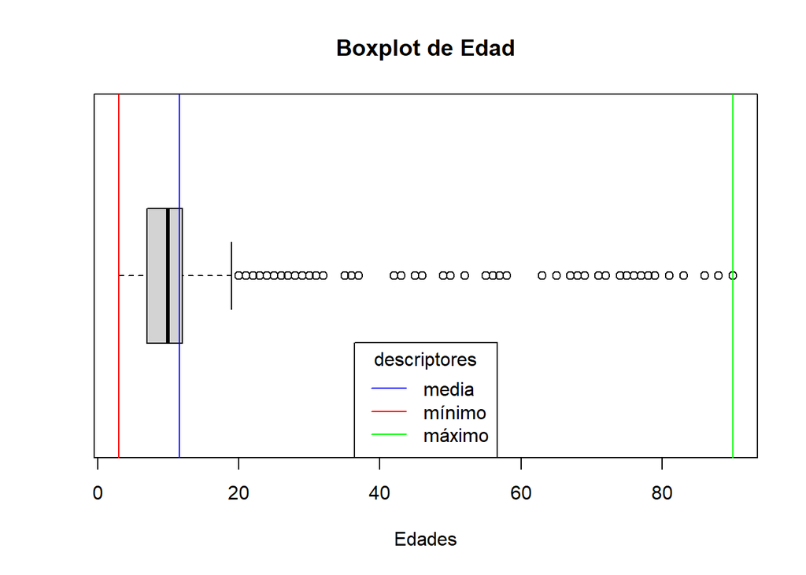

```r
boxplot(ED$Edad, horizontal = T , main= "Boxplot de Edad", xlab="Edades")
legend("bottom",legend = c("media" ,"mínimo", "máximo"), lty = c(1,1,1), col = c("blue","red","green"), title = "descriptores")
abline(v=min(ED$Edad), col= "red")
abline(v=max(ED$Edad), col= "green")
abline(v=mean(ED$Edad), col="blue")
```

En conclusión, esta variable presenta un grado alto de dispersión, ya que el rango intercuartil es pequeño en comparación al rango, además de que la desviación estándar también lo indica. Por otro lado, los descriptores de posición indican un sesgo a la derecha, el cual se ve reflejado en la gráfica.

### **Variable** `Género`

```r
ch <- redondeo(nrow(filter(ED, ED$Genero == "Hombre")))
cm <- redondeo(nrow(filter(ED, ED$Genero == "Mujer")))
```

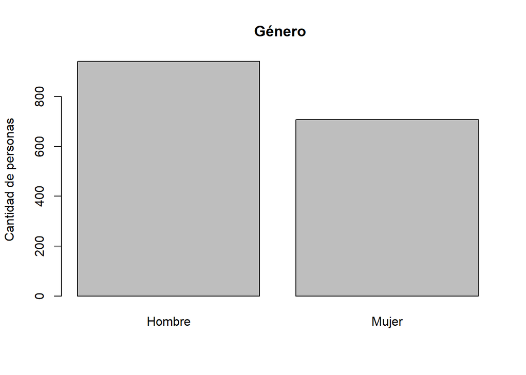

```r
barplot(table(ED$Genero), main=" Género", ylab="Cantidad de personas")
```

### **Variable** `Departamentos`

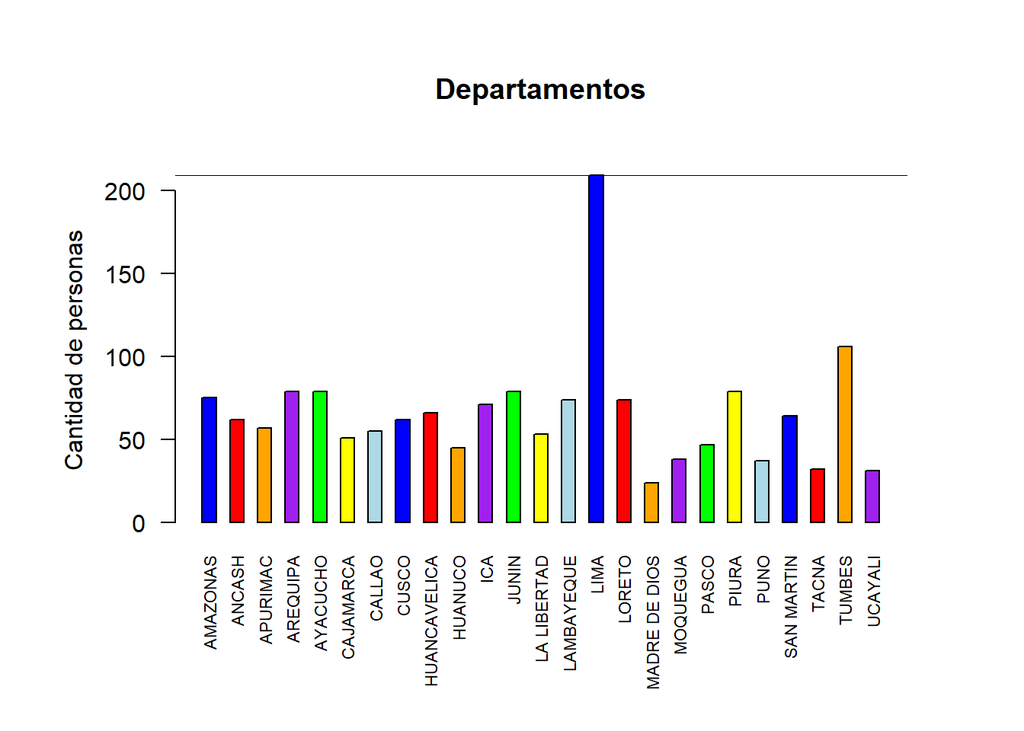

```r
maxC<-max(table(ED$Departamento))
x<- table(ED$Departamento)
color = c("blue","red","orange","purple","green","yellow", "light blue")
op<-par( mar= c(5,4,4,2)+2)
barplot(x, ylab="Cantidad de personas", ,main="Departamentos", col= color, horiz=FALSE, cex.names = 0.7,las=2, space = 1)
abline(h=maxC)
```

```r
par(op)
```

Se observa que en el departamento de Lima está presente con mayor frecuencia dentro de nuestra muestra. Esta cantidad es de 209 personas. La región que se encuentra en segundo lugar de la muestra es Tumbes con 106 personas.

### **Variable** `Limitacion permanente de extremidades`

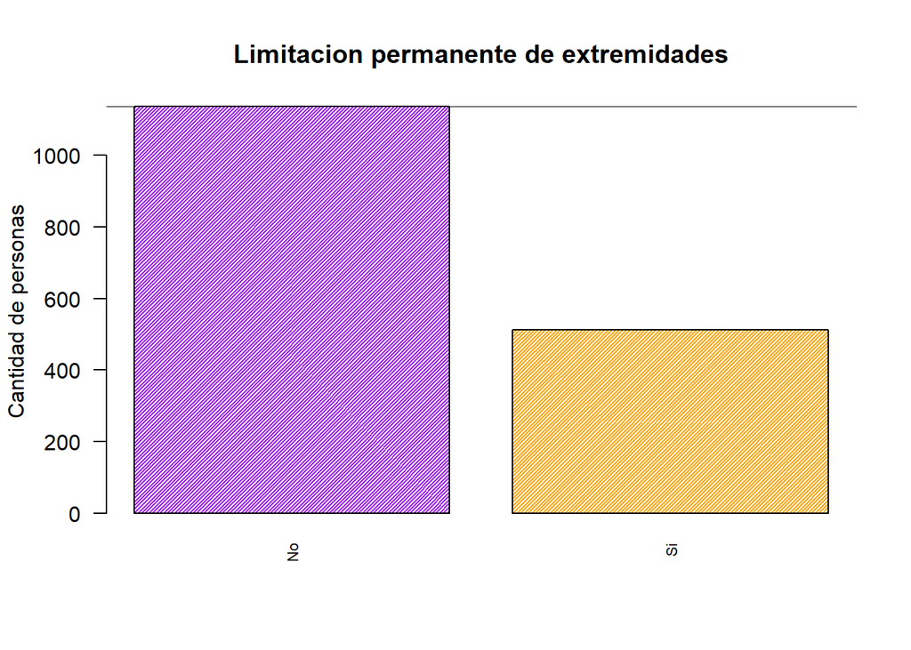

```r
maxC<-max(table(ED$Limitacion_permanente_extremidades))
minC<-min(table(ED$Limitacion_permanente_extremidades))
x<- table(ED$Limitacion_permanente_extremidades)
color = c("purple","orange")
barplot(x, ylab="Cantidad de personas", ,main="Limitacion permanente de extremidades", col= color, horiz=FALSE, cex.names = 0.7,las=2, density = 50, angle = 45)
abline(h=maxC)
```

Se observa que en el caso de Limitación permanente de extremidades la mayoría de personas de la muestra no la tienen los cuales son 1137 personas. Por el contrario las personas que si tienen esta discapacidad son 512.

### **Variable** `Limitacion permanente de la vista`

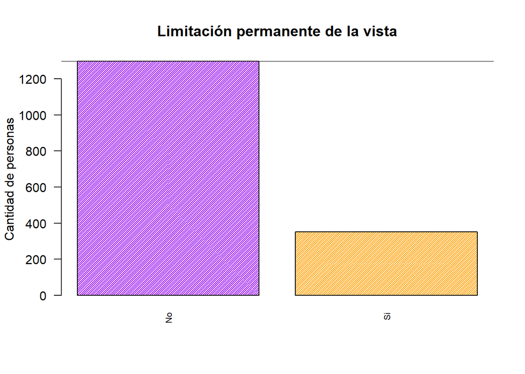

```r
maxC<-max(table(ED$Limitacion_permanente_vista ))
minC<-min(table(ED$Limitacion_permanente_vista))
x<- table(ED$Limitacion_permanente_vista )
color = c("purple","orange")
barplot(x, ylab="Cantidad de personas", ,main="Limitación permanente de la vista", col= color, horiz=FALSE, cex.names = 0.7,las=2, density = 50, angle = 45)
abline(h=maxC)
```

Se observa que en el caso de Limitación permanente de la vista la mayoría de personas de la muestra no la tienen los cuales son 1298 personas. Por el contrario las personas que si tienen esta discapacidad son 351.

### **Variable** `Limitacion permanente del habla`

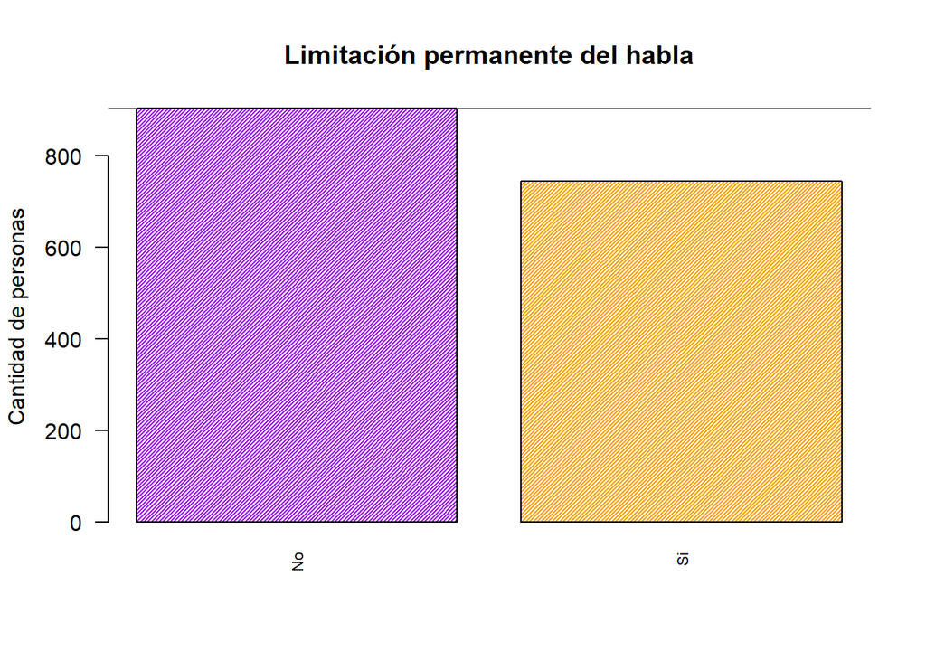

```r
maxC<-max(table(ED$Limitacion_permanente_habla ))
minC<-min(table(ED$Limitacion_permanente_habla))
x<- table(ED$Limitacion_permanente_habla )
color = c("purple","orange")
barplot(x, ylab="Cantidad de personas", ,main="Limitación permanente del habla", col= color, horiz=FALSE, cex.names = 0.7,las=2, density = 50, angle = 45)
abline(h=maxC)
```

Se observa que en el caso de Limitación permanente del habla la mayoría de personas de la muestra no la tienen los cuales son 904 personas. Por el contrario las personas que si tienen esta limitación son 745 pero la diferencia no es tanta como en las anteriores gráficas.

### **Variable** `Limitacion permanente del oido`

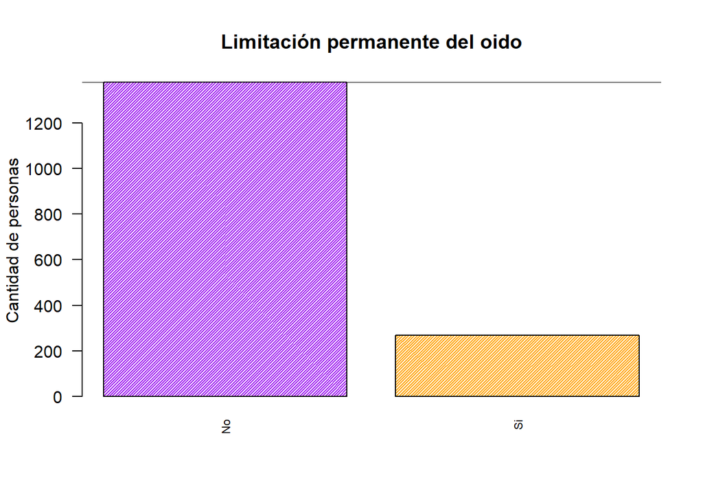

```r
maxC<-max(table(ED$Limitacion_permanente_oido))
minC<-min(table(ED$Limitacion_permanente_oido))
x<- table(ED$Limitacion_permanente_oido)
color = c("purple","orange")
barplot(x, ylab="Cantidad de personas", ,main="Limitación permanente del oido", col= color, horiz=FALSE, cex.names = 0.7,las=2, density = 50, angle = 45)
abline(h=maxC)
```

Se observa que en el caso de Limitación permanente del oido la mayoría de personas de la muestra no la tienen los cuales son 1380 personas. Por el contrario las personas que si tienen esta discapacidad son 269.

### **Variable** `Limitacion permanente para aprender`

[figure not shown]

```r
maxC<-max(table(ED$Limitacion_permanente_aprender ))
minC<-min(table(ED$Limitacion_permanente_aprender))
x<- table(ED$Limitacion_permanente_aprender )
color = c("purple","orange")
barplot(x, ylab="Cantidad de personas", ,main="Limitación permanente para aprender", col= color, horiz=FALSE, cex.names = 0.7,las=2, density = 50, angle = 45)
abline(h=maxC)
```

Se observa que en el caso de Limitación permanente para aprender la mayoría de personas de la muestra no la tienen los cuales son 870 personas. Por el contrario las personas que si tienen esta limitación son 779 pero no hay una gran diferencia diferencia.

### **Variable** `Limitacion permanente para relacionarse`

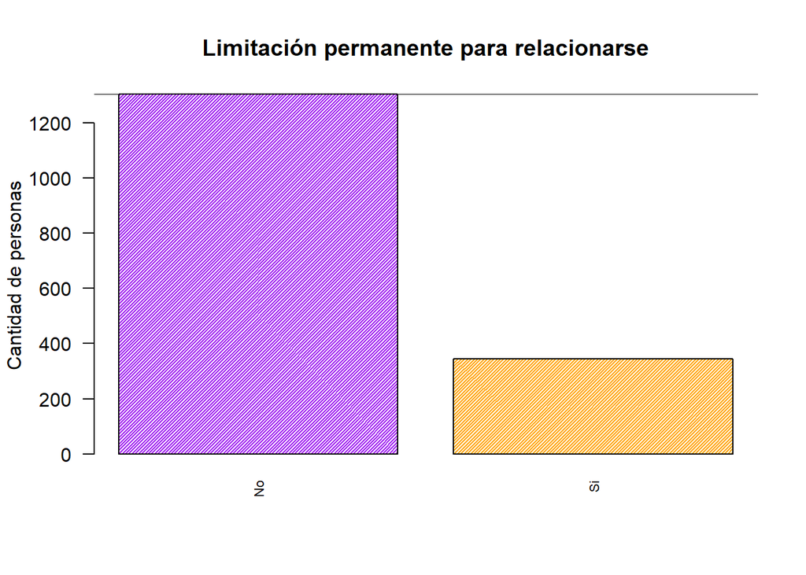

```r
maxC<-max(table(ED$Limitacion_permanente_reliacionarse ))
minC<-min(table(ED$Limitacion_permanente_reliacionarse))
x<- table(ED$Limitacion_permanente_reliacionarse )
color = c("purple","orange")
barplot(x, ylab="Cantidad de personas", ,main="Limitación permanente para relacionarse", col= color, horiz=FALSE, cex.names = 0.7,las=2, density = 50, angle = 45)
abline(h=maxC)
```

Se observa que en el caso de Limitación permanente para relacionarse la mayoría de personas de la muestra no la tienen los cuales son 1304 personas. Por el contrario las personas que si tienen esta discapacidad son 345.

### **Variable** `Enfermedad crónica que limita actividades`

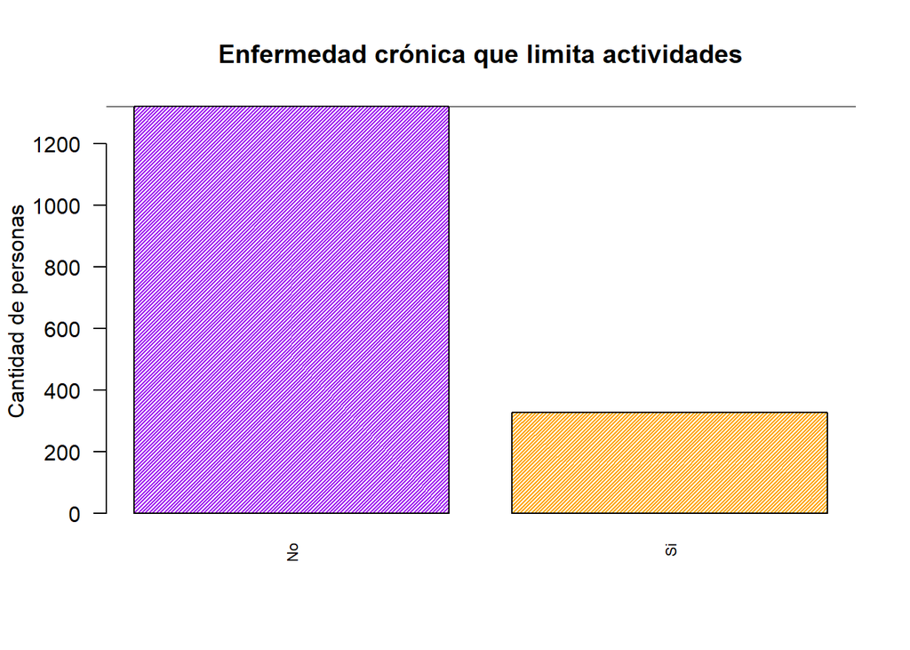

```r
maxC<-max(table(ED$Enfermedad_cronica_limita_actividades ))
minC<-min(table(ED$Enfermedad_cronica_limita_actividades))
x<- table(ED$Enfermedad_cronica_limita_actividades )
color = c("purple","orange")
barplot(x, ylab="Cantidad de personas", ,main="Enfermedad crónica que limita actividades", col= color, horiz=FALSE, cex.names = 0.7,las=2, density = 50, angle = 45)
abline(h=maxC)
```

Se observa que en el caso de enfermedad crónica que limita actividades la mayoría de personas de la muestra no la tienen los cuales son 1322 personas. Por el contrario las personas que si tienen esta discapacidad son 327.

### **Variable** `Sabe leer y escribir`

[figure not shown]

```r
maxC<-max(table(ED$Sabe_leer_y_escribir ))
minC<-min(table(ED$Sabe_leer_y_escribir))
x<- table(ED$Sabe_leer_y_escribir )
color = c("purple","orange")
barplot(x, ylab="Cantidad de personas", ,main="Sabe leer y escribir", col= color, horiz=FALSE, cex.names = 0.7,las=2, density = 50, angle = 45)
abline(h=maxC)
```

Se observa que en este caso la mayoría de personas de la muestra que saben leer y escribir son 954 personas. Por el contrario las personas que no pueden realizar esta actividad son 656 y la cantidad de personas que no especificaron si sabían son 39 que es la menor cantidad.

### **Variable** `Colegios con profesores especializados`

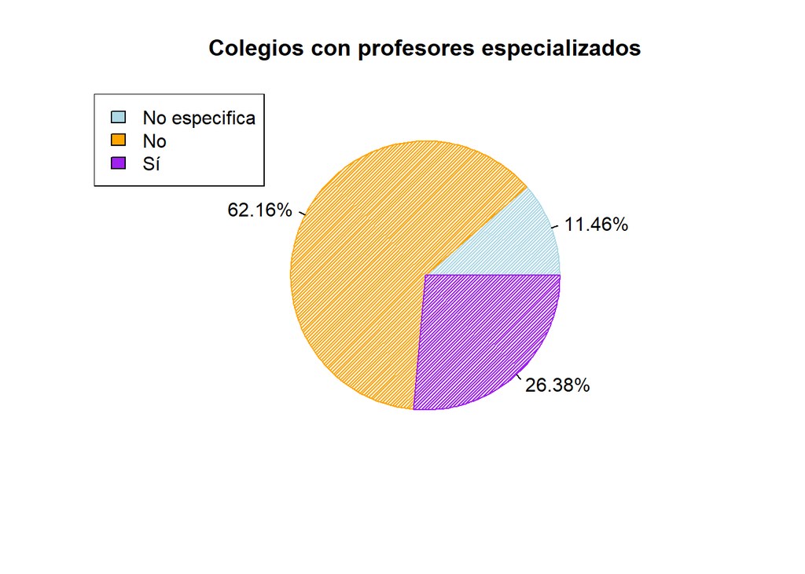

```r
maxC<-max(table(ED$Colegio_con_profesores_especializados))
minC<-min(table(ED$Colegio_con_profesores_especializados))
x<- table(ED$Colegio_con_profesores_especializados)
count_3 <- redondeo(c(x/nrow(ED))*100)
pie(count_3, labels = paste0(count_3, "%"),col=c("lightblue", "orange","purple"), density = 50, angle = 45,main="Colegios con profesores especializados")

legend("topleft", legend = c("No especifica", "No","Sí"),
       fill =  c("lightblue", "orange","purple"))
```

Se observa que en el caso los colegios con profesores especializados de la muestra son 435. Por el contrario que no cuentan con estos profesores son 1025 y la cantidad de personas que no especificaron si sabían son 189.

### **Variable** `Colegios con computadoras especializadas`

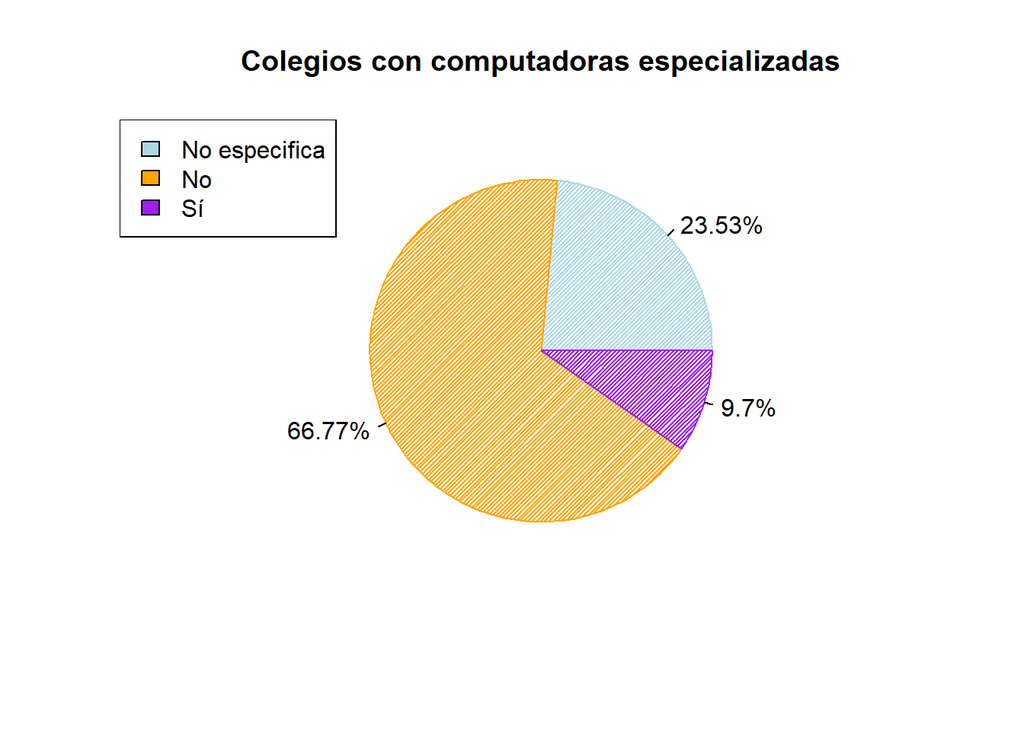

```r
maxC<-max(table(ED$Colegio_con_computadoras_especializadas ))
minC<-min(table(ED$Colegio_con_computadoras_especializadas))
x<- table(ED$Colegio_con_computadoras_especializadas )
count_3 <- redondeo(c(x/nrow(ED))*100)
pie(count_3, labels = paste0(count_3, "%"),col=c("lightblue", "orange","purple"), density = 50, angle = 45,main="Colegios con computadoras especializadas")

legend("topleft", legend = c("No especifica", "No","Sí"),
       fill =  c("lightblue", "orange","purple"))
```

Se observa que en el caso los colegios con computadoras especializadas de la muestra son 160. Por el contrario que no cuentan con esta tecnología son 1101 y la cantidad de personas que no especificaron si sabían son 388.

### **Variable** `Colegios con reproductor de audio y video`

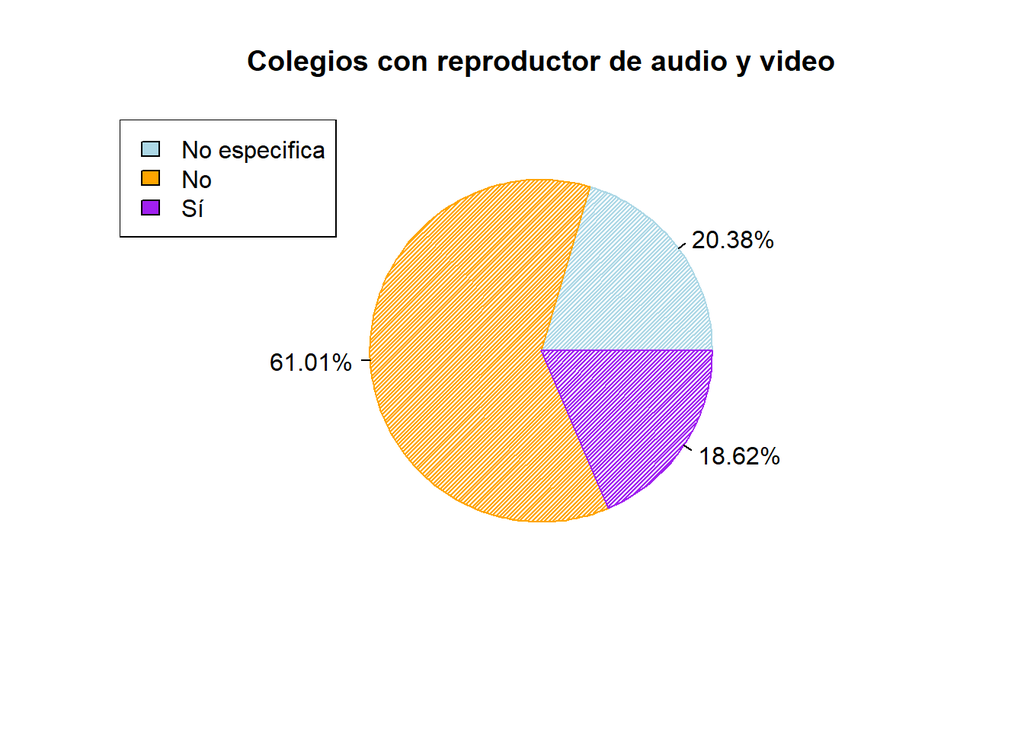

```r
maxC<-max(table(ED$Colegio_con_reproductor_audio_y_video ))
minC<-min(table(ED$Colegio_con_reproductor_audio_y_video))
x<- table(ED$Colegio_con_reproductor_audio_y_video )
count_3 <- redondeo(c(x/nrow(ED))*100)
pie(count_3, labels = paste0(count_3, "%"),col=c("lightblue", "orange","purple"), density = 50, angle = 45,main="Colegios con reproductor de audio y video")

legend("topleft", legend = c("No especifica", "No","Sí"),
       fill =  c("lightblue", "orange","purple"))
```

Se observa que en el caso los colegios con reproductor de audio y video de la muestra son 307. Por el contrario que no cuentan con esta tecnología son 1006 y la cantidad de personas que no especificaron si sabían son 336.

### **Variable** `Colegios con impresoras braille`

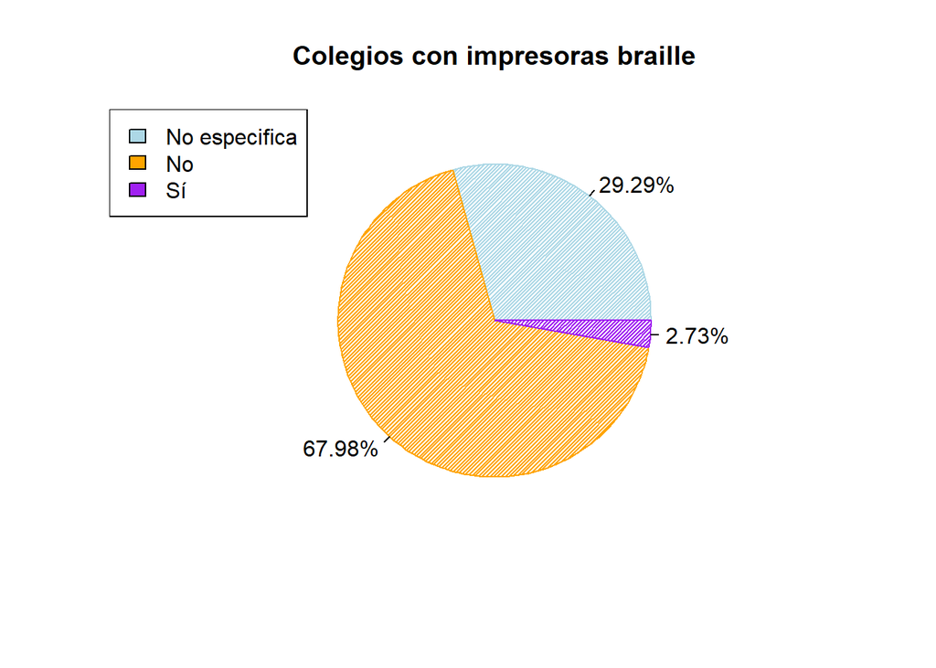

```r
maxC<-max(table(ED$Colegio_con_impresora_braille ))
minC<-min(table(ED$Colegio_con_impresora_braille))
x<- table(ED$Colegio_con_impresora_braille )
count_3 <- redondeo(c(x/nrow(ED))*100)
pie(count_3, labels = paste0(count_3, "%"),col=c("lightblue", "orange","purple"), density = 50, angle = 45,main="Colegios con impresoras braille")

legend("topleft", legend = c("No especifica", "No","Sí"),
       fill =  c("lightblue", "orange","purple"))
```

Se observa que en el caso los colegios con impresoras braille de la muestra son 45. Por el contrario que no cuentan con esta tecnología son 1121 y la cantidad de personas que no especificaron si sabían son 483.

### **Variable** `Colegios con libros braille`

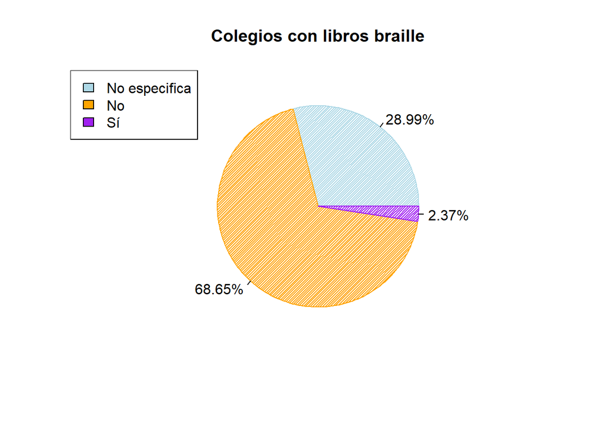

```r
maxC<-max(table(ED$Colegio_con_libros_braille ))
minC<-min(table(ED$Colegio_con_libros_braille))
x<- table(ED$Colegio_con_libros_braille )
count_3 <- redondeo(c(x/nrow(ED))*100)
pie(count_3, labels = paste0(count_3, "%"),col=c("lightblue", "orange","purple"), density = 50, angle = 45,main="Colegios con libros braille")

legend("topleft", legend = c("No especifica", "No","Sí"),
       fill =  c("lightblue", "orange","purple"))
```

Se observa que en el caso los colegios con libros braille de la muestra son 39. Por el contrario que no cuentan con estos libros son 1132 y la cantidad de personas que no especificaron si sabían son 478.

### **Variable** `Colegios con libros hablados`

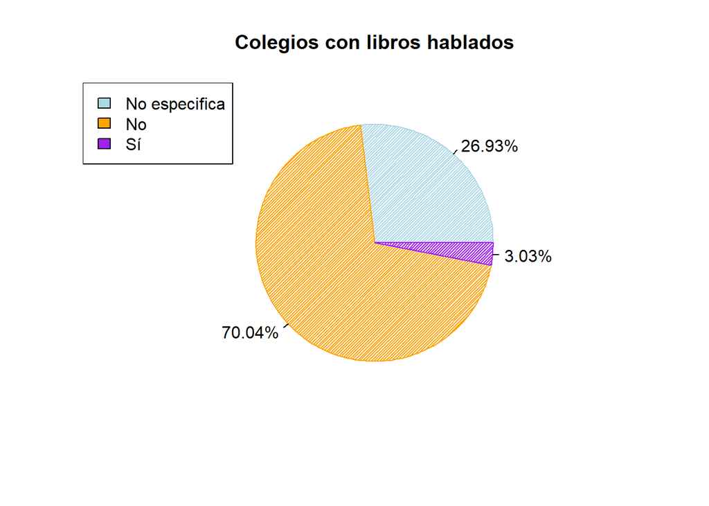

```r
maxC<-max(table(ED$Colegio_con_libros_hablados ))
minC<-min(table(ED$Colegio_con_libros_hablados))
x<- table(ED$Colegio_con_libros_hablados )
count_3 <- redondeo(c(x/nrow(ED))*100)
pie(count_3, labels = paste0(count_3, "%"),col=c("lightblue", "orange","purple"), density = 50, angle = 45,main="Colegios con libros hablados")

legend("topleft", legend = c("No especifica", "No","Sí"),
       fill =  c("lightblue", "orange","purple"))
```

Se observa que en el caso los colegios con libros hablados de la muestra son 50. Por el contrario que no cuentan con estos libros son 1155 y la cantidad de personas que no especificaron si sabían son 444.

### **Variable** `Colegios con lenguaje de señas`

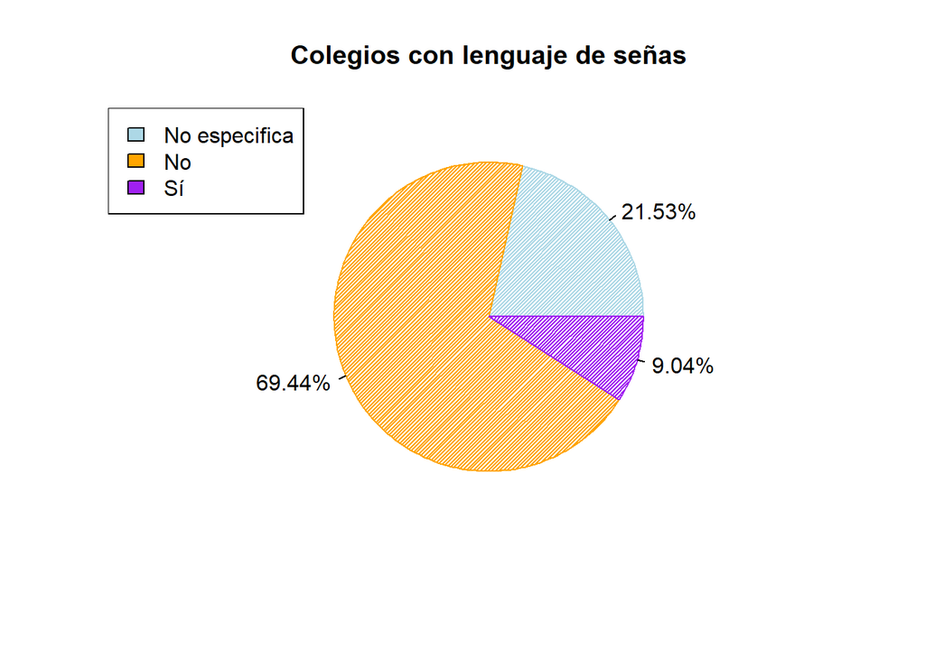

```r
maxC<-max(table(ED$Colegio_con_lenguaje_señas))
minC<-min(table(ED$Colegio_con_lenguaje_señas))
x<- table(ED$Colegio_con_lenguaje_señas)
count_3 <- redondeo(c(x/nrow(ED))*100)
pie(count_3, labels = paste0(count_3, "%"),col=c("lightblue", "orange","purple"), density = 50, angle = 45,main="Colegios con lenguaje de señas")

legend("topleft", legend = c("No especifica", "No","Sí"),
       fill =  c("lightblue", "orange","purple"))
```

Se observa que en el caso los colegios con lenguaje de señas de la muestra son 149. Por el contrario que no cuentan con este lenguaje son 1145 y la cantidad de personas que no especificaron si sabían son 355.

### **Variable** `Colegios con leguaje dactilológico`

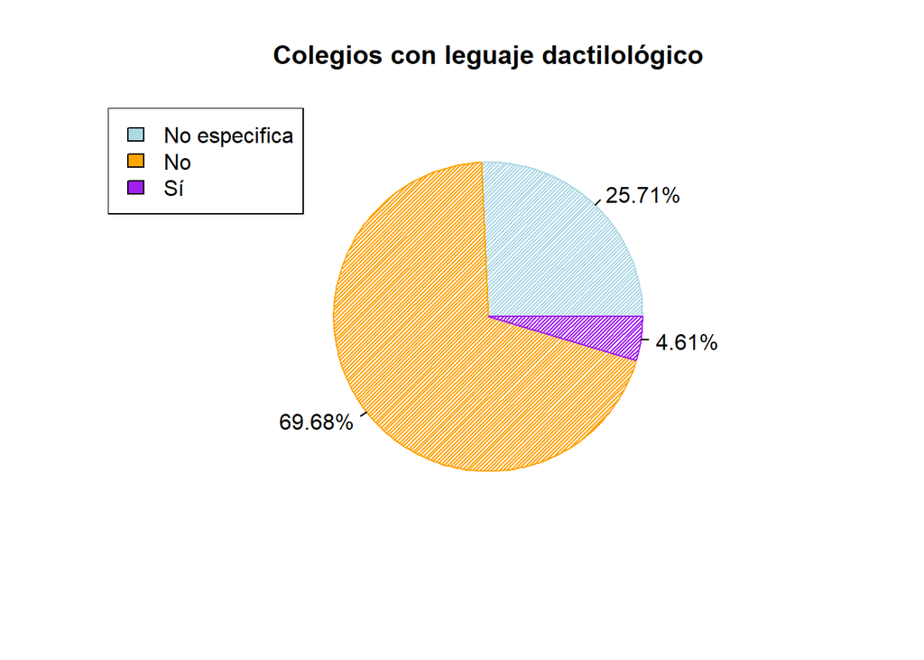

```r
maxC<-max(table(ED$Colegio_con_lenguaje_dactilologico ))
minC<-min(table(ED$Colegio_con_lenguaje_dactilologico))
x<- table(ED$Colegio_con_lenguaje_dactilologico )
count_3 <- redondeo(c(x/nrow(ED))*100)
pie(count_3, labels = paste0(count_3, "%"),col=c("lightblue", "orange","purple"), density = 50, angle = 45,main="Colegios con leguaje dactilológico")

legend("topleft", legend = c("No especifica", "No","Sí"),
       fill =  c("lightblue", "orange","purple"))
```

Se observa que en el caso los colegios con lenguaje dactilológico de la muestra son 76. Por el contrario que no cuentan con este lenguaje son 1149 y la cantidad de personas que no especificaron si sabían son 424.

### **Variable** `Colegios con rampas de acceso`

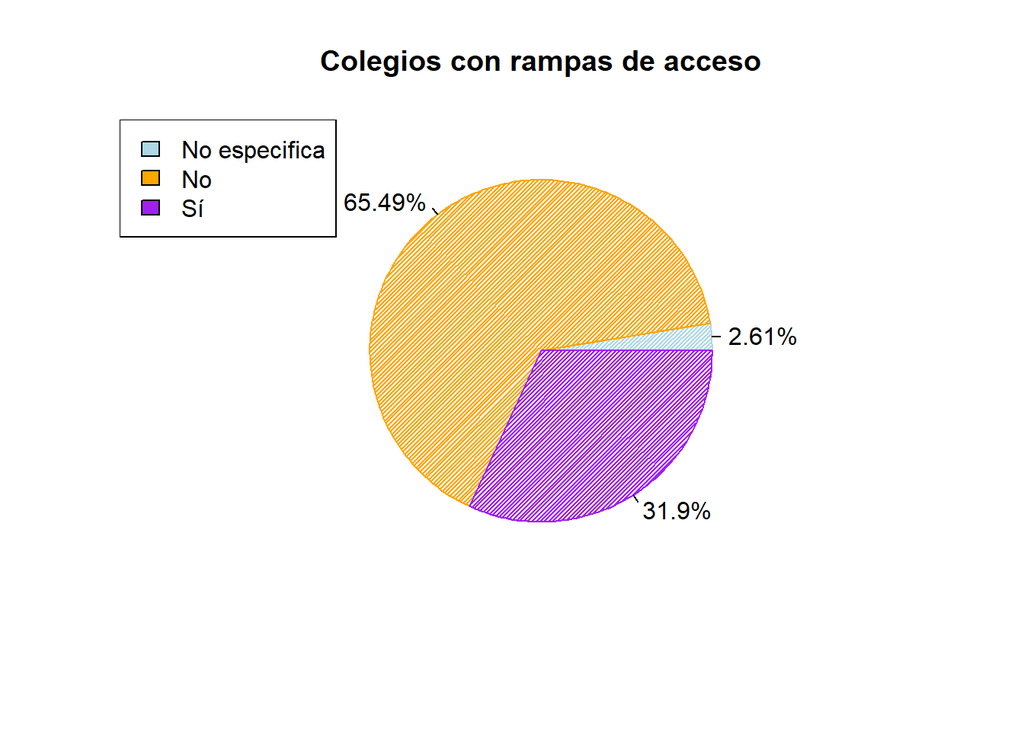

```r
maxC<-max(table(ED$Colegio_con_rampas_de_acceso ))
minC<-min(table(ED$Colegio_con_rampas_de_acceso))
x<- table(ED$Colegio_con_rampas_de_acceso )
count_3 <- redondeo(c(x/nrow(ED))*100)
pie(count_3, labels = paste0(count_3, "%"),col=c("lightblue", "orange","purple"), density = 50, angle = 45,main="Colegios con rampas de acceso")

legend("topleft", legend = c("No especifica", "No","Sí"),
       fill =  c("lightblue", "orange","purple"))
```

Se observa que en el caso los colegios con rampas de acceso de la muestra son 526. Por el contrario que no cuentan con rampas son 1080 y la cantidad de personas que no especificaron si sabían son 43.

### **Variable** `Colegios con barandas de seguridad`

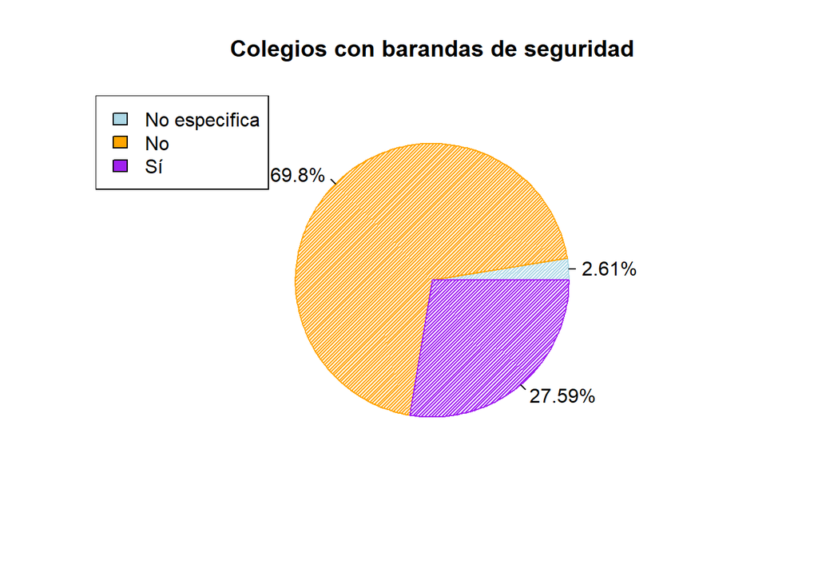

```r
maxC<-max(table(ED$Colegio_con_barandas_de_seguridad ))
minC<-min(table(ED$Colegio_con_barandas_de_seguridad))
x<- table(ED$Colegio_con_barandas_de_seguridad )
count_3 <- redondeo(c(x/nrow(ED))*100)
pie(count_3, labels = paste0(count_3, "%"),col=c("lightblue", "orange","purple"), density = 50, angle = 45,main="Colegios con barandas de seguridad")

legend("topleft", legend = c("No especifica", "No","Sí"),
       fill =  c("lightblue", "orange","purple"))
```

Se observa que en el caso los colegios con barandas de seguridad de la muestra son 455. Por el contrario que no cuentan con barandas son 1151 y la cantidad de personas que no especificaron si sabían son 43.

### **Variable** `Colegios con ascensores adecuados`

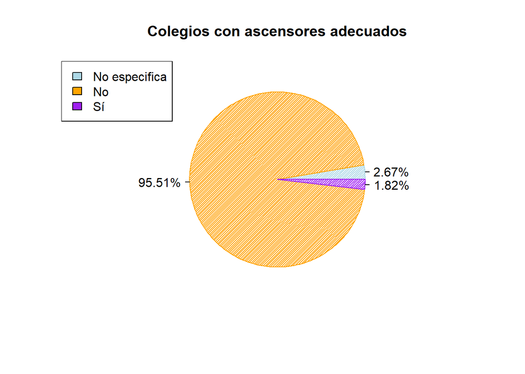

```r
maxC<-max(table(ED$Colegio_con_ascensores_adecuados ))
minC<-min(table(ED$Colegio_con_ascensores_adecuados))
x<- table(ED$Colegio_con_ascensores_adecuados )
count_3 <- redondeo(c(x/nrow(ED))*100)
pie(count_3, labels = paste0(count_3, "%"),col=c("lightblue", "orange","purple"), density = 50, angle = 45,main="Colegios con ascensores adecuados")

legend("topleft", legend = c("No especifica", "No","Sí"),
       fill =  c("lightblue", "orange","purple"))
```

Se observa que en el caso los colegios con ascensores adecuados de la muestra son 30. Por el contrario que no cuentan con ascensores son 1575 y la cantidad de personas que no especificaron si sabían son 44.

### **Variable** `Colegios con sshh para personas discapacitadas`

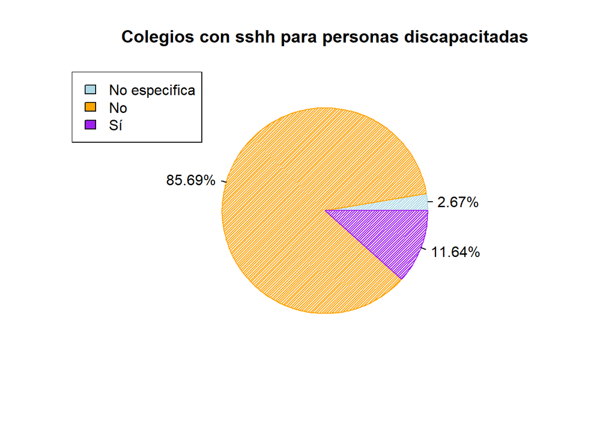

```r
maxC<-max(table(ED$Colegio_con_sshh_discapacitados ))
minC<-min(table(ED$Colegio_con_sshh_discapacitados))
x<- table(ED$Colegio_con_sshh_discapacitados )
count_3 <- redondeo(c(x/nrow(ED))*100)
pie(count_3, labels = paste0(count_3, "%"),col=c("lightblue", "orange","purple"), density = 50, angle = 45,main="Colegios con sshh para personas discapacitadas")

legend("topleft", legend = c("No especifica", "No","Sí"),
       fill =  c("lightblue", "orange","purple"))
```

Se observa que en el caso los colegios con sshh para personas discapacitadas de la muestra son 192. Por el contrario que no cuentan con sshh para discapacitados son 1413 y la cantidad de personas que no especificaron si sabían son 44.

### **Variable** `Colegios con canales de información`

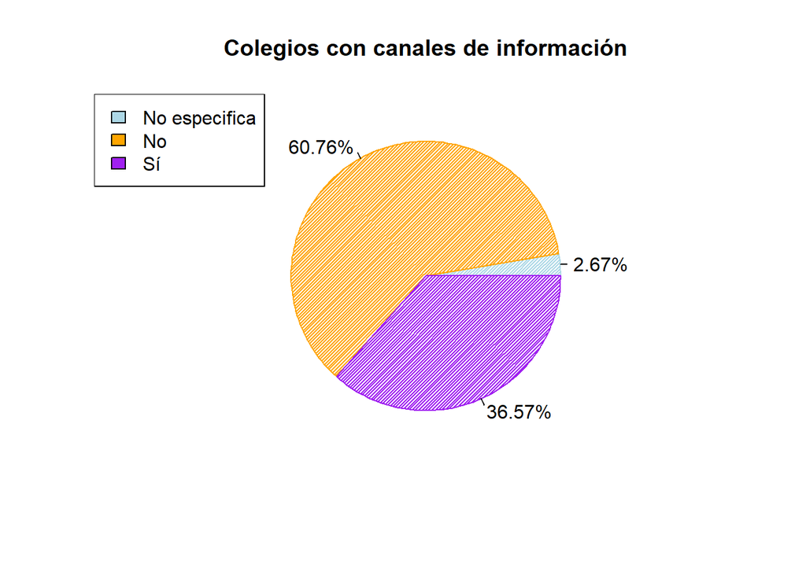

```r
maxC<-max(table(ED$Colegio_con_carteles_de_informacion))
minC<-min(table(ED$Colegio_con_carteles_de_informacion))
x<- table(ED$Colegio_con_carteles_de_informacion)
count_3 <- redondeo(c(x/nrow(ED))*100)
pie(count_3, labels = paste0(count_3, "%"),col=c("lightblue", "orange","purple"), density = 50, angle = 45,main="Colegios con canales de información")

legend("topleft", legend = c("No especifica", "No","Sí"),
       fill =  c("lightblue", "orange","purple"))
```

Se observa que en el caso los colegios con canales de información de la muestra son 603. Por el contrario que no cuentan con estos canales son 1002 y la cantidad de personas que no especificaron si sabían son 44.

### **Variable** `Colegios con lenguaje alternativo`

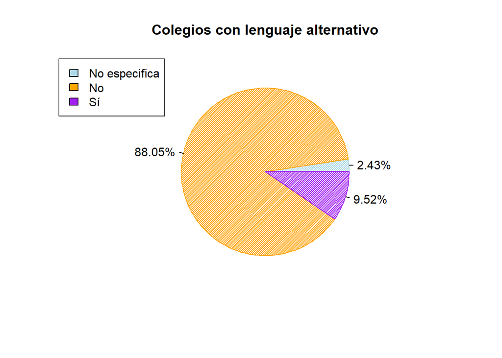

```r
maxC<-max(table(ED$Conoce_lenguaje_alternativo ))
minC<-min(table(ED$Conoce_lenguaje_alternativo))
x<- table(ED$Conoce_lenguaje_alternativo )

count_3 <- redondeo(c(x/nrow(ED))*100)
pie(count_3, labels = paste0(count_3, "%"),col=c("lightblue", "orange","purple"), density = 50, angle = 45,main="Colegios con lenguaje alternativo")

legend("topleft", legend = c("No especifica", "No","Sí"),
       fill =  c("lightblue", "orange","purple"))
```

Se observa que en el caso los colegios con lenguaje alternativo de la muestra son 157. Por el contrario que no cuentan con estos lenguajes son 1452 y la cantidad de personas que no especificaron si sabían son 40.

### **Variable** `Idioma que habla`

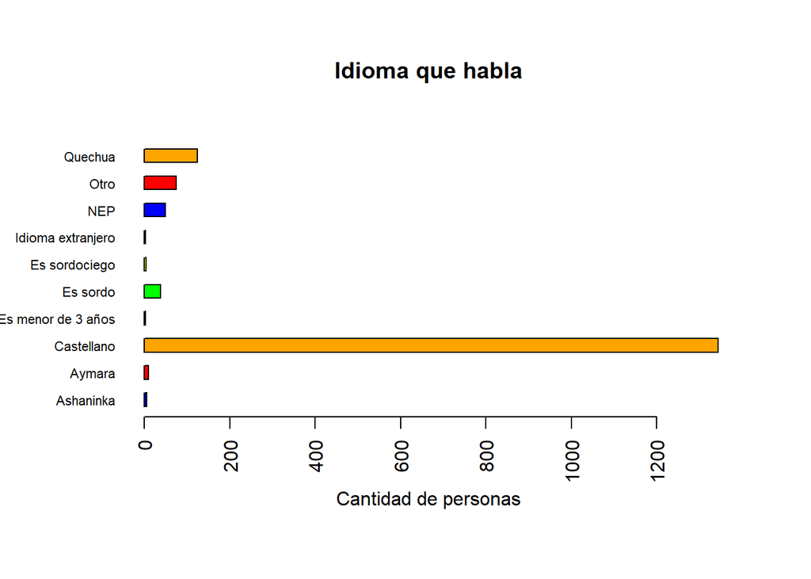

```r
maxC<-max(table(ED$Idioma_que_habla  ))
x<- table(ED$Idioma_que_habla  )
color = c("blue","red","orange","purple","green","yellow", "light blue")
op<-par( mar= c(5,4,4,2)+2)
barplot(x, xlab="Cantidad de personas", ,main="Idioma que habla", col= color, horiz=TRUE, cex.names = 0.7,las=2, space = 1)
abline(h=maxC)
```

```r
par(op)
```

En esta gráfica se puede apreciar que la mayoría de personas se comunican con el idioma castellano con un total de 1344 hablantes.

## **Bivariado**

Para este apartado decidimos unir las discapacidades por tipos tales como: discapacidad física, discapacidad intelectual, discapacidad psicosocial y discapacidad sensorial. Lo mismo se hizo con los colegios que cumplen con ciertos requisitos para ser aptos para personas con discapacidad dividida en infraestructura, personal capacitado, tecnologías especializadas y materiales necesarios para enseñar.

| **TIPOS DE DISCAPACIDADES** | **DISCAPACIDADES** \| **NUMERO DE PERSONAS** |  |  |  |
| --- | --- | --- | --- | --- |
| Discapacidad física | Enfermedad_cronica_limita_actividades \| 327 personas Limitacion_permanente_extremidades \| 512 personas = 839 total |  |  |  |
| Discapacidad intelectual | Limitacion_permanente_aprender |  |  | 779 personas |
| Discapacidad psicosocial | Limitacion_permanente_reliacionarse |  |  | 345 personas |

```r
t1 <- data.frame(ED$Limitacion_permanente_extremidades, ED$Enfermedad_cronica_limita_actividades)

t1 <- t1 %>%
  mutate(Discapacidad_Fisica = if_else(ED.Limitacion_permanente_extremidades == "Si" | ED.Enfermedad_cronica_limita_actividades == "Si", "Si", "No"))
```

```r
t4 <- data.frame(ED$Limitacion_permanente_vista, ED$Limitacion_permanente_oido, ED$Limitacion_permanente_habla)

t4 <- t4 %>%
  mutate(Discapacidad_Sensorial = if_else(ED.Limitacion_permanente_vista == "Si" | ED.Limitacion_permanente_oido == "Si" | ED.Limitacion_permanente_habla == "Si", "Si", "No"))
```

```r
tb1 <- cbind(t1["Discapacidad_Fisica"], ED["Limitacion_permanente_aprender"], ED["Limitacion_permanente_reliacionarse"], t4["Discapacidad_Sensorial"])
```

| **COLEGIOS CON** | **REQUERIDOS** | **N° Colegios** \| |
| --- | --- | --- |
| Infraestructura | Colegio_con_rampas_de_acceso Colegio_con_barandas_de_seguridad Colegio_con_ascensores_adecuados Colegio_con_sshh_discapacitados Colegio_con_carteles_de_informacion | 526 colegios 455 colegios 30 colegios 192 colegios 603 colegios |
| Personal capacitado | Colegio_con_profesores_especializados | 435 colegios |
| Tecnologías especializadas | Colegio_con_computadoras_especializadas Colegio_con_reproductor_audio_y_video Colegio_con_impresora_braille Colegio_con_libros_hablados | 160 colegios 307 colegios 45 colegios 50 colegios |

```r
ED %>% filter(Colegio_con_carteles_de_informacion== "Si") %>% count(Colegio_con_carteles_de_informacion)
```

| Colegio_con_carteles_de_informacion | n |
| --- | --- |
| Si | 603 |

```r
t5 <- data.frame(ED$Colegio_con_rampas_de_acceso, ED$Colegio_con_barandas_de_seguridad, ED$Colegio_con_ascensores_adecuados,ED$Colegio_con_sshh_discapacitados,ED$Colegio_con_carteles_de_informacion)

t5 <- t5 %>%
  mutate(Infraestructura = if_else(ED.Colegio_con_rampas_de_acceso == "Si" | ED.Colegio_con_barandas_de_seguridad == "Si"| ED.Colegio_con_ascensores_adecuados == "Si" | ED.Colegio_con_sshh_discapacitados == "Si"| ED.Colegio_con_carteles_de_informacion == "Si", "Si", "No"))
```

```r
t7 <- data.frame(ED$Colegio_con_computadoras_especializadas, ED$Colegio_con_reproductor_audio_y_video, ED$Colegio_con_impresora_braille,ED$Colegio_con_libros_hablados)

t7 <- t7 %>%
  mutate( Tecnologias_especializadas = if_else(ED.Colegio_con_computadoras_especializadas == "Si" | ED.Colegio_con_reproductor_audio_y_video == "Si"| ED.Colegio_con_impresora_braille == "Si" | ED.Colegio_con_libros_hablados == "Si", "Si", "No"))
```

```r
t8 <- data.frame(ED$Colegio_con_libros_braille, ED$Colegio_con_lenguaje_señas, ED$Colegio_con_lenguaje_dactilologico )

t8 <- t8 %>%
  mutate( Materiales_necesarios_para_enseñar = if_else(ED.Colegio_con_libros_braille == "Si" | ED.Colegio_con_lenguaje_señas == "Si"| ED.Colegio_con_lenguaje_dactilologico == "Si", "Si", "No"))
```

```r
tb2 <- cbind(t5["Infraestructura"], ED["Colegio_con_profesores_especializados"], t7["Tecnologias_especializadas"], t8["Materiales_necesarios_para_enseñar"])
```

Eliminamos las Variables que no son relevantes para nuestro estudio o que tienen gran cantidad de datos vacíos:

```r
borrar <- c("Limitacion_permanente_extremidades","Limitacion_permanente_vista","Limitacion_permanente_habla","Limitacion_permanente_oido","Limitacion_permanente_aprender","Limitacion_permanente_reliacionarse","Enfermedad_cronica_limita_actividades","Tiene_alguna_limitacion","Sabe_leer_y_escribir","Colegio_con_profesores_especializados","Colegio_con_computadoras_especializadas", "Colegio_con_reproductor_audio_y_video","Colegio_con_impresora_braille","Colegio_con_libros_braille","Colegio_con_libros_hablados","Colegio_con_lenguaje_señas",              "Colegio_con_lenguaje_dactilologico", "Colegio_con_rampas_de_acceso","Colegio_con_barandas_de_seguridad","Colegio_con_ascensores_adecuados","Colegio_con_sshh_discapacitados", "Colegio_con_carteles_de_informacion" )
EDP <- ED[ , !(names(ED) %in% borrar)]
```

Las tablas creadas anteriormente se añadirán a la principal dando como resultado EDP con 35 variables.

```r
EDP<-cbind(EDP,tb1)
EDP<-cbind(EDP,tb2)
```

### Variables `Género` y `Departamento` vs `Discapacidad física`

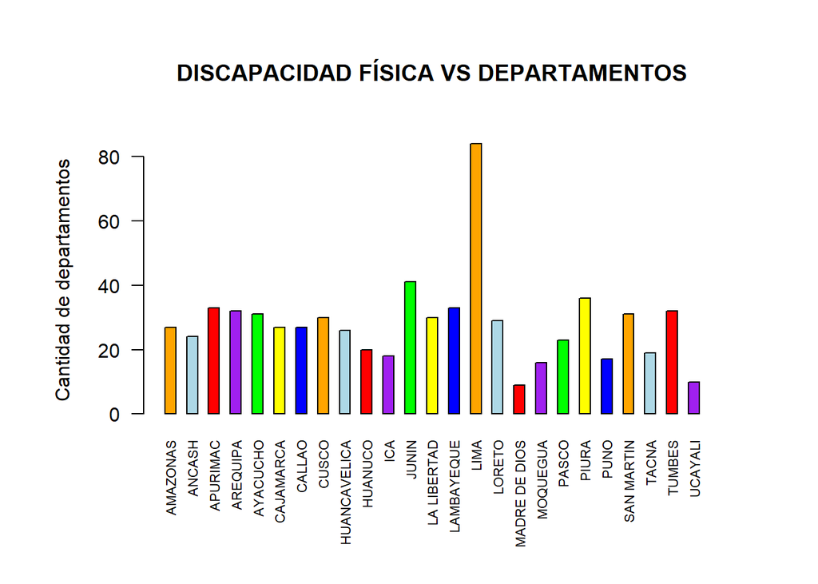

```r
disc_fisic<-filter(EDP,EDP$Discapacidad_Fisica=="Si")
color = c("orange","light blue","red","purple","green","yellow", " blue")
op<-par( mar= c(5,4,4,2)+2.15)
barplot(table(disc_fisic$Departamento), ylab="Cantidad de departamentos", ,main="DISCAPACIDAD FÍSICA VS DEPARTAMENTOS", col= color, horiz=FALSE, cex.names = 0.7,las=2, space = 1)
```

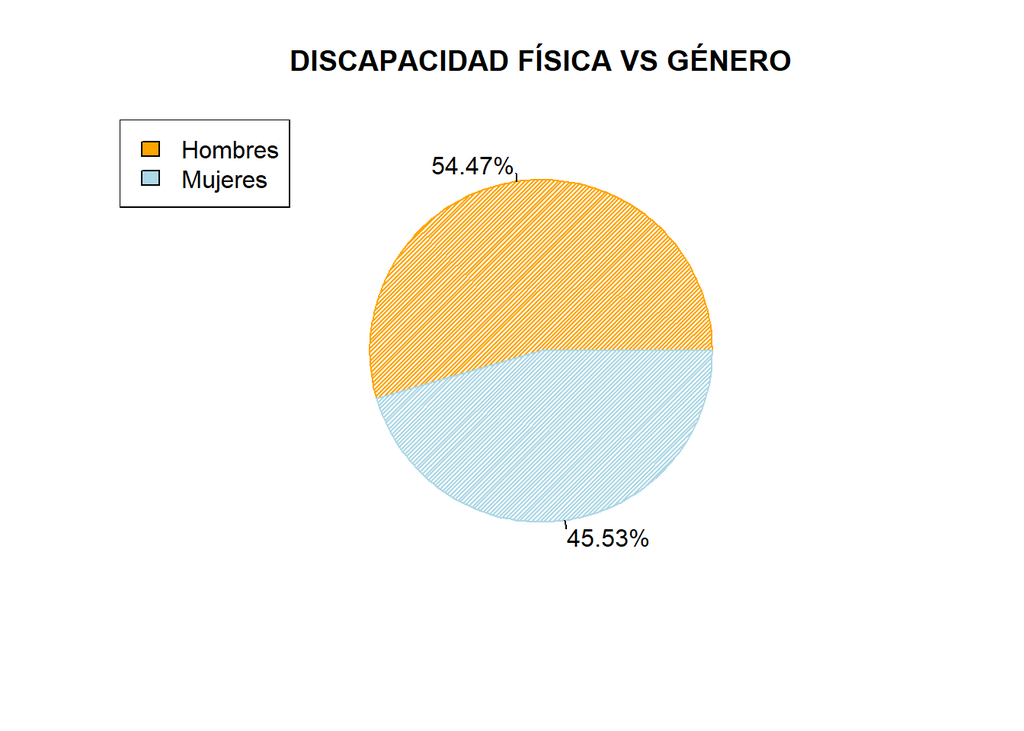

```r
par(op)
count_3 <- redondeo(c((table(disc_fisic$Genero)/nrow(disc_fisic))*100))
pie(count_3, labels = paste0(count_3, "%"),col=c("orange", "lightblue"), density = 50, angle = 45,main="DISCAPACIDAD FÍSICA VS GÉNERO")

legend("topleft", legend = c("Hombres", "Mujeres"),
       fill =  c("orange", "lightblue"))
```

En las gráfica de discapacidad física por departamento podemos observar que la mayor cantidad de estas personas en la muestra se encuentran en el departamento de Lima y la menor cantidad se encuentra en Madre de Dios. En la gráfica de discapacidad física por género podemos observar que en nuestra la el hombre sufre más de esta discapacidad.

### Variables `Género` y `Departamento` vs `Discapacidad intelectual`

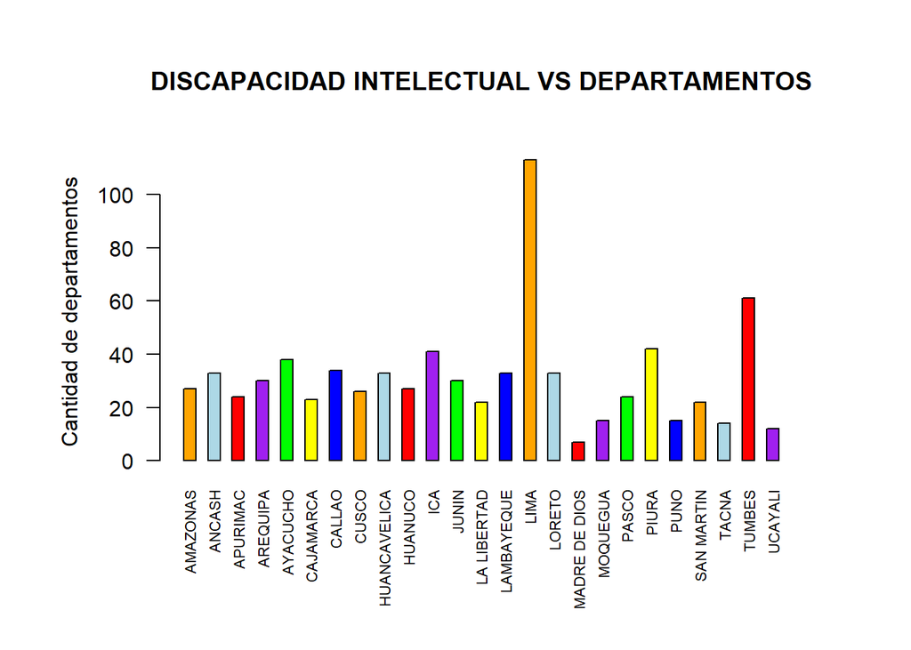

```r
limit_aprender<-filter(EDP,EDP$Limitacion_permanente_aprender=="Si")
color = c("orange","light blue","red","purple","green","yellow", " blue")
op<-par( mar= c(5,4,4,2)+2.15)
barplot(table(limit_aprender$Departamento), ylab="Cantidad de departamentos" ,main="DISCAPACIDAD INTELECTUAL VS DEPARTAMENTOS", col= color, horiz=FALSE, cex.names = 0.7,las=2, space = 1)
```

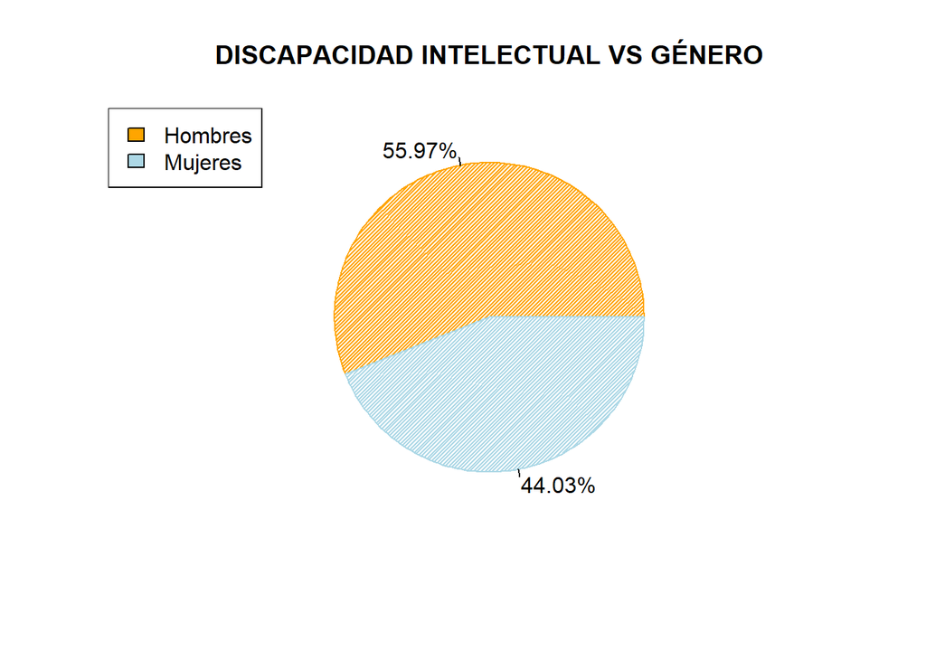

```r
par(op)
count_3 <- redondeo(c((table(limit_aprender$Genero)/nrow(limit_aprender))*100))
pie(count_3, labels = paste0(count_3, "%"),col=c("orange", "lightblue"), density = 50, angle = 45,main="DISCAPACIDAD INTELECTUAL VS GÉNERO")

legend("topleft", legend = c("Hombres", "Mujeres"),
       fill =  c("orange", "lightblue"))
```

En las gráfica de discapacidad intelectual por departamento podemos observar que la mayor cantidad de estas pesonas en la muestra se encuentran en el departamento de Lima, también podemos observar que tumbes se encuentra como segundo lugar en la cantidad de personas con esta discapacidad y finalmente la menor cantidad se encuentra en Madre de Dios. En la gráfica de discapacidad intelectual por género podemos observar que en la muestra el hombre sufre más de esta discapacidad.

### Variables `Género` y `Departamento` vs `Discapacidad psicosocial`

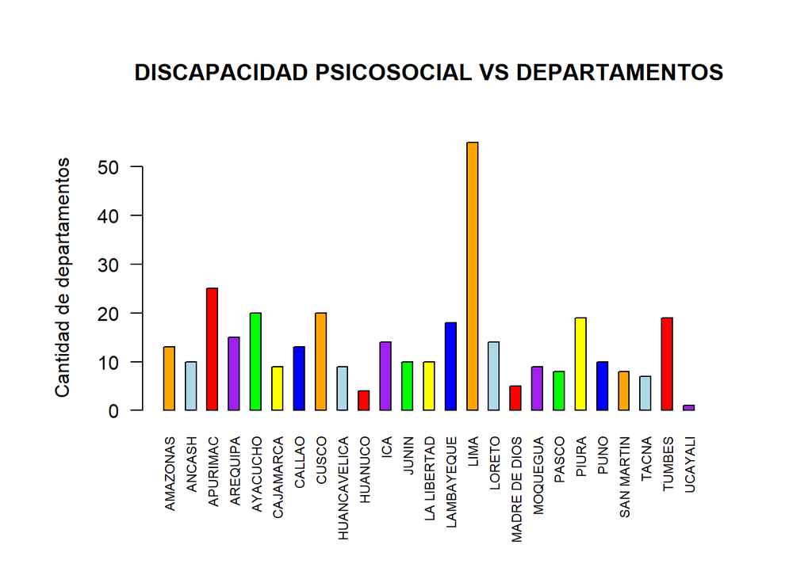

```r
limit_relacion<-filter(EDP,EDP$Limitacion_permanente_reliacionarse=="Si")
color = c("orange","light blue","red","purple","green","yellow", " blue")
op<-par( mar= c(5,4,4,2)+2.15)
barplot(table(limit_relacion$Departamento), ylab="Cantidad de departamentos", ,main="DISCAPACIDAD PSICOSOCIAL VS DEPARTAMENTOS", col= color, horiz=FALSE, cex.names = 0.7,las=2, space = 1)
```

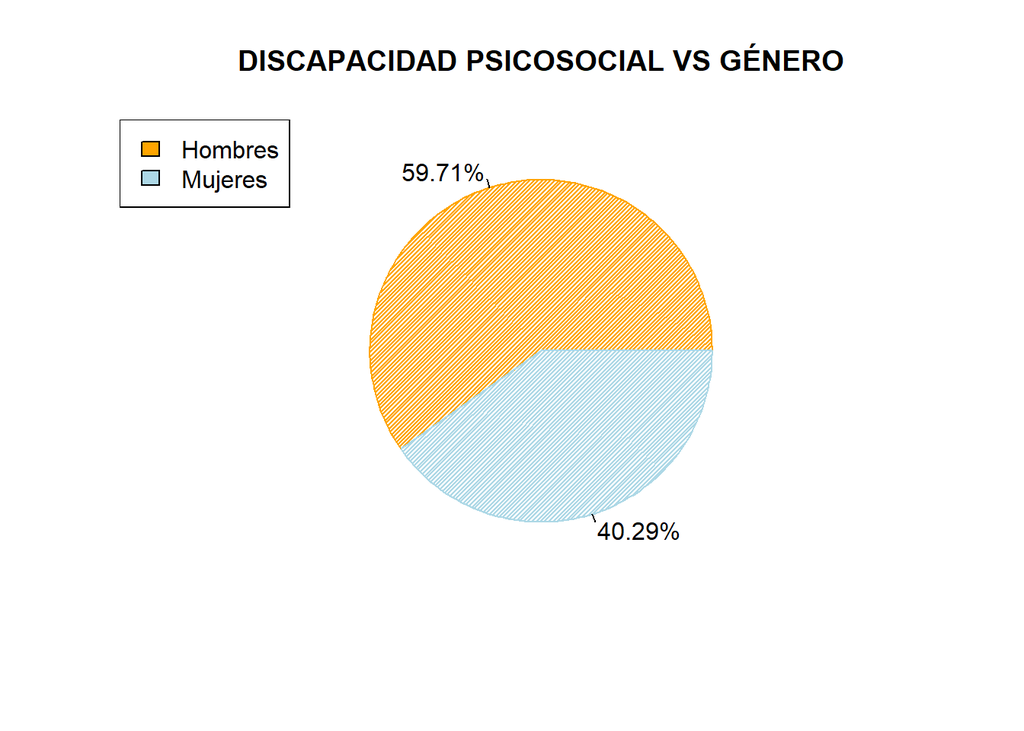

```r
par(op)
count_3 <- redondeo(c((table(limit_relacion$Genero)/nrow(limit_relacion))*100))
pie(count_3, labels = paste0(count_3, "%"),col=c("orange", "lightblue"), density = 50, angle = 45,main="DISCAPACIDAD PSICOSOCIAL VS GÉNERO")

legend("topleft", legend = c("Hombres", "Mujeres"),
       fill =  c("orange", "lightblue"))
```

En las gráfica de discapacidad psicosocial por departamento podemos observar que la mayor cantidad de estas personas en la muestra se encuentran en el departamento de Lima y la menor cantidad se encuentra en Ucayali. En la gráfica de discapacidad psicosocial por género podemos observar que en la muestra el hombre sufre más de esta discapacidad.